# Final Report - An analysis of Bike Vendors data

Vishal Bhalla

April 22, 2019

#### 1. Introduction

This document contains the analysis done on the **Bike Vendors** data set. The report is being prepared as part of the final submission for the *Applied Data Science* class.

First we load the data into a Data Frame and then analyse its features. We then formulate our questions that we need to get the answers for. Thereafter we use the techniques we learnt to get those answers from the data provided.

```r
bike_raw <- read_csv("../CodePortfolio/R/Data/bikeVendors.csv") # Read the data
```

#### 2. Questions that need to be answered

- Which bike sells more? Mountain Bike or Road Bike?
- Which store sells most bikes?
- What is the cost of a bike?

#### 3. Understand the data

We see that there are **35** variables and **97** obeservations for each variable. There are no missing values.

The variable names are displayed below.

```
##                  colnames(bike)
## 1                         model
## 2                     category1
## 3                     category2
## 4                         frame
## 5                         price
## 6            albuquerque_cycles
## 7               ann_arbor_speed
## 8               austin_cruisers
## 9              cincinnati_speed
## 10      columbus_race_equipment
## 11                dallas_cycles
## 12             denver_bike_shop
## 13               detroit_cycles
## 14     indianapolis_velocipedes
```

[output cut: 21 more lines]

The **model** variable contains the name of the bike model, the **category1** variable contain the category of the bike, i.e. if it is a Mountain Bike or a Road bike and **category2** further sub categorize it by usage like Sports or Elite Road bike for example. The **Frame** variable contains the details on the type of frame ‘Carbon’ or ‘Aluminium’ and **Price** contains the price of the frame.

The data under each vendor name has a sum total of 1, so it appears to be the percentage of each type of frame sold by the vendor totalling to 100%.

Looking at the data, I think more appropriate questions to ask would be:

- What is the percentage market share for bikes based on frame type?
- What is the percentage market share for Mountain Bike and Road Bike?
- What is the price range where most of the bikes sell?

#### 4. Analysis - Sales

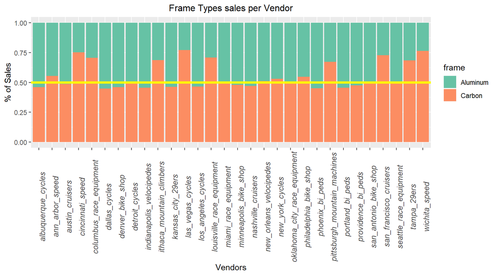

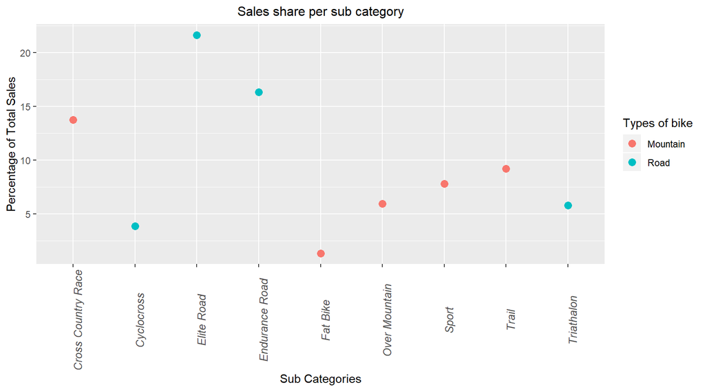

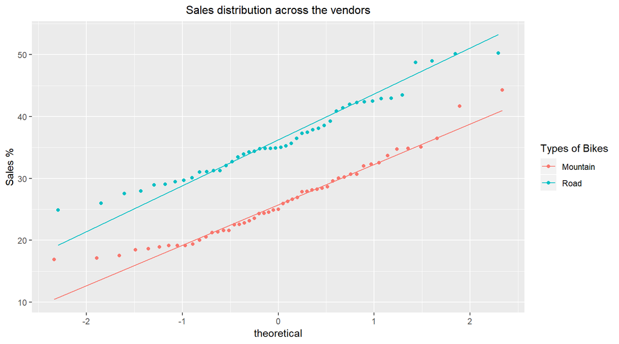

The sales of the bikes across the various vendors seems to follow almost a normal distribution with some outliers at both the lower and higher edges of the data.

#### 5. Analysis - Price

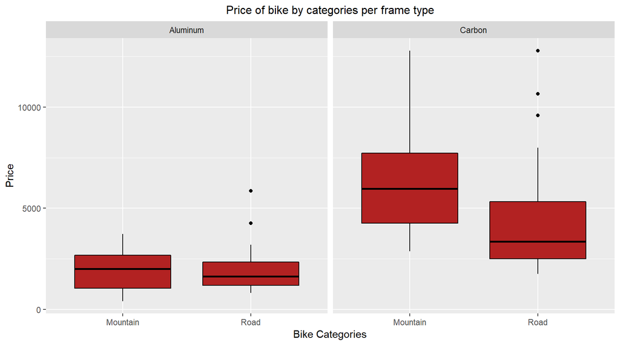

The box plots above show that the Carbon frame bikes are expensive when compared to the Aluminum frame bikes. The bikes that fall under the Mountain bike category are expensive than the road bikes. The most expensive bikes are the Mountain Bikes with Carbon frame with the median price aroud $6000.

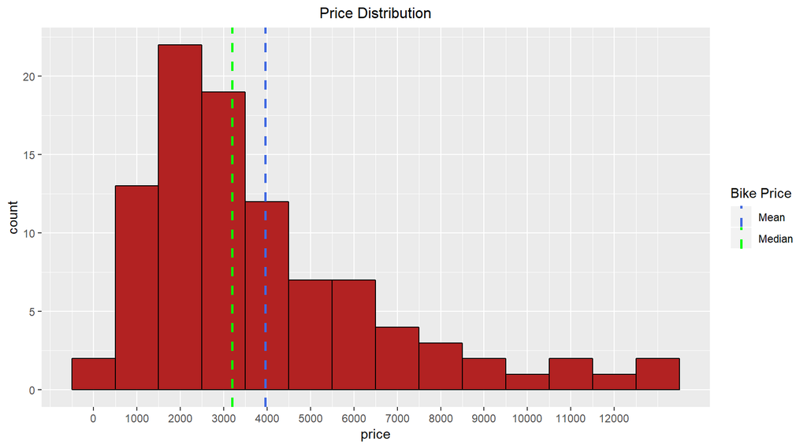

The histogram above shows the price distribution for the bikes. We observe that the major number of bikes sold are less than the overall mean price of the bikes. Majority of the bikes range between the price of $500 - $4500.

#### 6. Analysis - Cluster

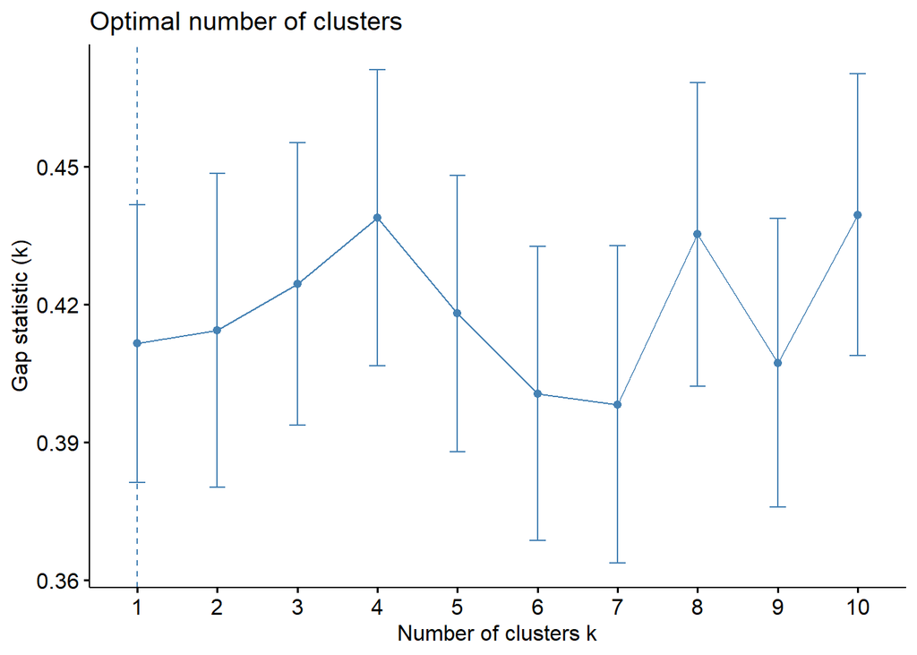

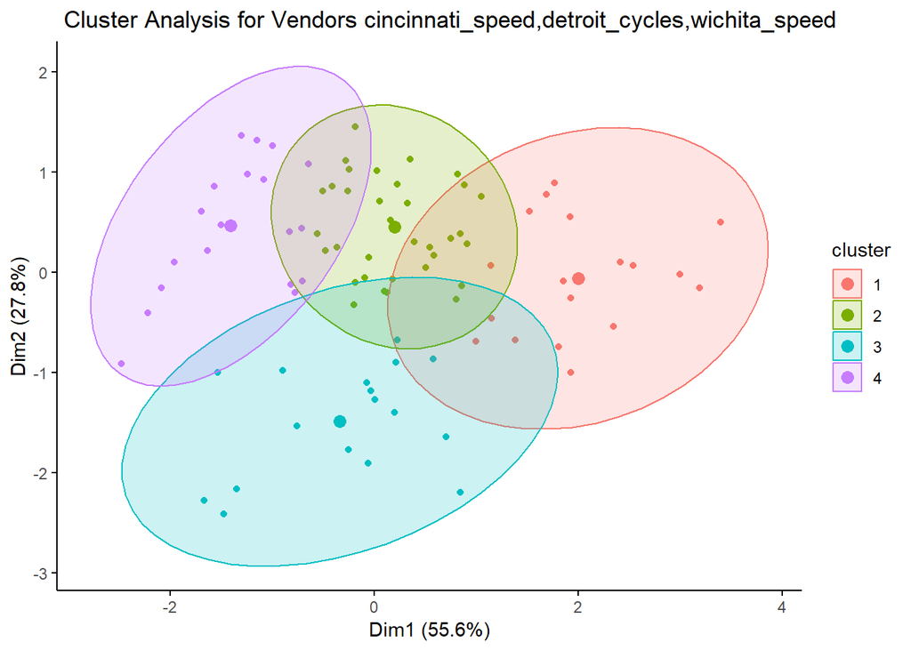

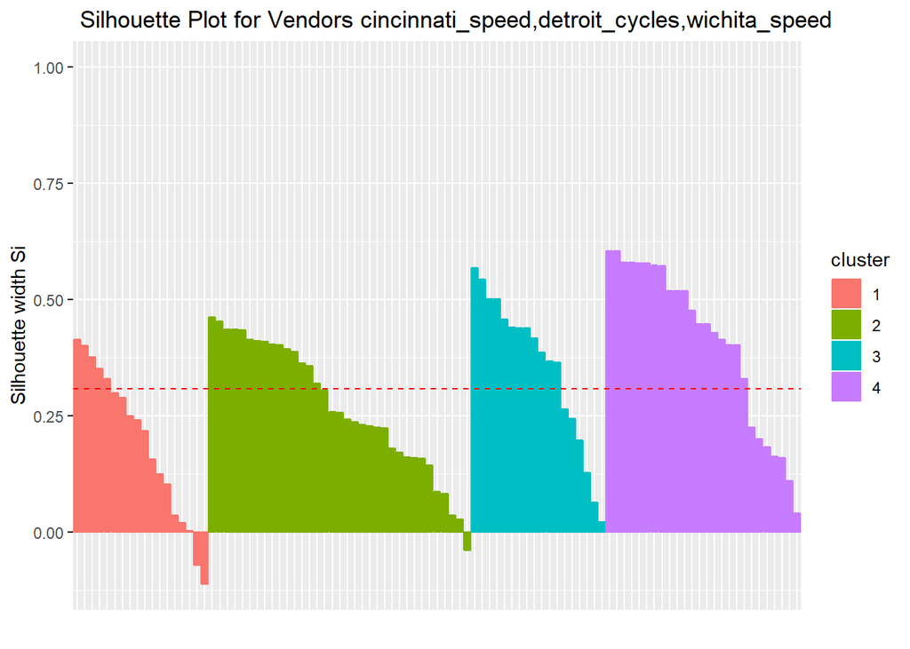

```
## Cluster Size:
```

```
## [1] 18 35 18 26
```

As the number of vendors is large we selected 3 vendors randomly(“cincinnati_speed”, “detroit_cycles”,“wichita_speed”) and performed the kmeans clustering on the same.

The 4 clusters formed are clear but overlapping. This indicates that the data in itself is not contain natural clusters. The same can be interpreted with the Silhoutte plot where we see that all the clusters are having around 50% affect i.e. the observations fall under 2 clusters. There are even negative observations suggesting that the points are categorized under incorrect clusters.

#### 7. Analysis - Regression

```
## Mean of Sales Total:
```

```
## [1] 0.3092783
```

```
## Mean of Price:
```

```
## [1] 3953.763
```

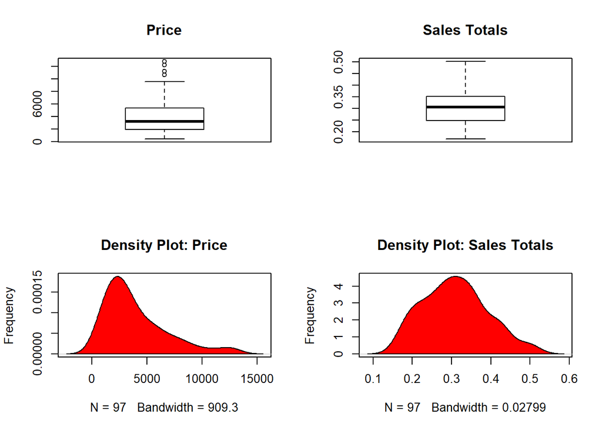

We perform the regression analysis of the bike vendors data, with the sum of each row as our dependant variable and the price of the bike as independent variable.

The boxplot and density plots above show that the “Sales Total” for each row of the data is normally distributed and is shaped almost like a bell curve. The density plot for “Price” shows that it is skewed towards the right. The boxplot for price shows that there are few outliers.

The formula we use here is **lm(totalbyrow~price, data=bike)**

The NULL Hypothesis here is that the sales of the bikes have a strong relationship with price of the bike. If we get a small p value it would mean that our NULL Hypothesis should be rejected.

```
##
## Call:
## lm(formula = totalbyrow ~ price, data = bike)
##
## Residuals:
##       Min        1Q    Median        3Q       Max
## -0.139356 -0.054989 -0.002734  0.041871  0.182469
##
## Coefficients:
##               Estimate Std. Error t value Pr(>|t|)
## (Intercept)  3.647e-01  1.231e-02  29.627  < 2e-16 ***
## price       -1.401e-05  2.523e-06  -5.551 2.57e-07 ***
## ---
## Signif. codes:  0 '***' 0.001 '**' 0.01 '*' 0.05 '.' 0.1 ' ' 1
##
## Residual standard error: 0.071 on 95 degrees of freedom
## Multiple R-squared:  0.2449, Adjusted R-squared:  0.2369
## F-statistic: 30.81 on 1 and 95 DF,  p-value: 2.57e-07
```

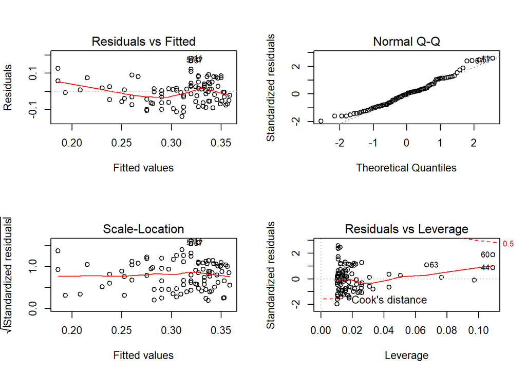

The residuals vs fitted graph does not show any particuar pattern. This would mean that there is no non-linear relationship between the predicted and actual observations that would have resulted in the data points being left out.

The residuals almost follow a normal distribution which is a good sign for the linear model. There are some outliers at both the ends though.

The scale location line is almost horizontal, which means that the residuals are well distributed across the range of observations which is a good sign.

There are no outliers beyong the cooks like(dashed red line) which would mean that there are no outliers which have affect on the regression if they are omitted. Therefore we can ignore those observations.

#### 8. Conclusion

The boxplots “Price of bike by categories per frame type” provide us the visualalization that the Carbon frame bikes are expensive when compared to the Aluminum frame bikes. The “Price Distibution” histogram presents the facts that majority of the bike modesl are available in the price range of $500 - $4500. The mean price of a bike is ~$4000 while the median price is $3250. This difference in mean and median means that there are outliers in the data, which would be the expensive Carbon framed bikes.